# Proyecto-Facebook-Metrics

Cristina, Lucia, Alonso

2025-02-09

```r
knitr::opts_chunk$set(
  warning = FALSE,
  message = FALSE
)
```

```r
library(readr)
library(ggplot2)
library(dplyr)
library(knitr)
library(pheatmap)
library(lmtest)
library(glmnet)
library(caret)
library(splines)
library(MASS)
library(car)
library(pROC)
```

# Introducción

**Información de los autores** Este proyecto ha sido realizado por el grupo 9 del grado de Ciencia e Ingeniería de datos para la asignatura de Modelos de Regresión que cuanta con los siguientes integrantes:

- **Cristina Rodríguez Ayllón**
- **Lucía Arnaldo Cuevas**
- **Alonso Rescalvo Casas**

El trabajo ha sido repartido de la siguiente manera:

- EDA: Cristina, Lucía y Alonso
- Modelos de regresión lineal: Cristina y Lucía
- Métodos de selección de variables y problemas de regularización: Cristina y Lucía
- Modelos no lineales: Alonso

Nuestro datasetes es el de “Facebook Metrics Dataset”. Es un conjunto de datos que recopila diversas métricas relacionadas con la interacción de los usuarios en páginas de Facebook. Estas métricas incluyen información sobre impresiones, alcance, interacciones con publicaciones, entre otras.

```r
# lectura de datos
dataset_Facebook <- read_delim("dataset_Facebook.csv",
    delim = ";", escape_double = FALSE, trim_ws = TRUE)
#View(dataset_Facebook)
#datos<-read.csv("datos/datos.csv")
ntotal <- dim(dataset_Facebook)[1] # numero de observaciones
ptotal <- dim(dataset_Facebook)[2] # numero de columnas
```

Comprobamos que tenemos $n=$500 observaciones y $p=$19 variables en la base de datos.

Según la descripción oficial de los datos, las variables que conforman el conjunto de datos son:

## Tabla descriptiva de las variables

```r
# Crear un data frame con las descripciones de las variables
tabla_variables <- data.frame(
  Variable = c("Page total likes", "Type", "Category", "Post Month", "Post Weekday",
               "Post Hour", "Paid", "Lifetime Post Total Reach", "Lifetime Post Total Impressions",
               "Lifetime Engaged Users", "Lifetime Post Consumers", "Lifetime Post Consumptions",
               "Lifetime Post Impressions by people who have liked your Page",
               "Lifetime Post reach by people who like your Page",
               "Lifetime People who have liked your Page and engaged with your post",
               "comment", "like", "share", "Total Interactions"),

  Tipo = c("Numérica", "Categórica", "Categórica", "Numérica", "Numérica",
           "Numérica", "Binaria", "Numérica", "Numérica",
           "Numérica", "Numérica", "Numérica",
           "Numérica", "Numérica",
           "Numérica", "Numérica", "Numérica", "Numérica", "Numérica"),

  Descripción = c("Cantidad total de 'me gusta' en la página",
                  "Tipo de post (foto, estado, video, etc.)",
                  "Categoría del post",
                  "Mes en el que se realizó la publicación",
                  "Día de la semana en que se publicó",
                  "Hora del día en que se publicó",
                  "Indica si la publicación fue pagada (1) o no (0)",
                  "Alcance total de la publicación",
                  "Total de impresiones de la publicación",
                  "Usuarios comprometidos con la publicación",
                  "Número de consumidores de la publicación",
                  "Total de interacciones con la publicación",
                  "Impresiones por personas que han dado 'me gusta' a la página",
                  "Alcance de la publicación por personas que han dado 'me gusta' a la página",
                  "Personas que dieron 'me gusta' a la página e interactuaron con la publicación",
                  "Número de comentarios en la publicación",
                  "Número de 'me gusta' en la publicación",
                  "Número de veces que se compartió la publicación",
                  "Total de interacciones (comentarios, likes y compartidos)")
)

# Mostrar la tabla en formato bonito
kable(tabla_variables, caption = "Descripción de las Variables del Dataset")
```

Descripción de las Variables del Dataset

| Variable | Tipo | Descripción |
| --- | --- | --- |
| Page total likes | Numérica | Cantidad total de ‘me gusta’ en la página |
| Type | Categórica | Tipo de post (foto, estado, video, etc.) |
| Category | Categórica | Categoría del post |
| Post Month | Numérica | Mes en el que se realizó la publicación |
| Post Weekday | Numérica | Día de la semana en que se publicó |
| Post Hour | Numérica | Hora del día en que se publicó |
| Paid | Binaria | Indica si la publicación fue pagada (1) o no (0) |
| Lifetime Post Total Reach | Numérica | Alcance total de la publicación |
| Lifetime Post Total Impressions | Numérica | Total de impresiones de la publicación |
| Lifetime Engaged Users | Numérica | Usuarios comprometidos con la publicación |
| Lifetime Post Consumers | Numérica | Número de consumidores de la publicación |
| Lifetime Post Consumptions | Numérica | Total de interacciones con la publicación |
| Lifetime Post Impressions by people who have liked your Page | Numérica | Impresiones por personas que han dado ‘me gusta’ a la página |
| Lifetime Post reach by people who like your Page | Numérica | Alcance de la publicación por personas que han dado ‘me gusta’ a la página |
| Lifetime People who have liked your Page and engaged with your post | Numérica | Personas que dieron ‘me gusta’ a la página e interactuaron con la publicación |
| comment | Numérica | Número de comentarios en la publicación |
| like | Numérica | Número de ‘me gusta’ en la publicación |
| share | Numérica | Número de veces que se compartió la publicación |
| Total Interactions | Numérica | Total de interacciones (comentarios, likes y compartidos) |

# EDA

## Preguntas a resolver pre-EDA

**¿Cuántas observaciones hay?¿Cuántas variables/características están medidas?**

```r
dim(dataset_Facebook)
```

```
## [1] 500  19
```

Hay 500 observaciones y 19 variables

**¿Existen valores faltantes?**

```r
sum(is.na(dataset_Facebook))
```

```
## [1] 6
```

Hay 6 valores faltantes. Más adelante los trataremos.

**¿Qué tipo variables aparecen en la base de datos?** Todas nuestras variables son discretas. A excepcion de un par que son categóticas.

**¿Qué variables son discretas?¿Cuáles son continuas?¿Qué categorías tienen las variables?¿Hay variables tipo texto?**

Todas estas preguntas se resuelven mirando la tabla descriptiva que generamos anteriormente.

**Variable objetivo: ¿Existe una variable de “respuesta”? ¿Binaria o multiclase?** Sí, la variable de respuesta es “Total Interactions”. Como estamos en un proyecto de regresión, esta variable es numérica continua y no es binaria ni multiclase.

**¿Es posible identificar variables irrelevantes?. Estudiar variables relevantes requiere, habitualmente, métodos estadísticos.** Sí, pero para hacerlo correctamente hay que aplicar métodos estadísticos como matrices de correlación.

**¿Es posible identificar la distribución que siguen las variables?** Sí, se puede hacer con gráficos y pruebas estadísticas como: Histogramas para visualizar la forma de la distribución; Boxplots para detectar outliers y asimetrías; Q-Q Plots para comparar con una distribución normal; Pruebas estadísticas como Shapiro-Wilk; o Kolmogorov-Smirnov para evaluar normalidad.

## Partición de los datos

Realizamos la división de nuestros datos en 3 muestras: entrenamiento, validación y test.

```r
# mediante una semilla conseguimos que el ejercicio sea reproducible
set.seed(1)


# creamos índices
indices <- 1:ntotal
ntrain <- ntotal * .5
ntest <- ntotal * .25
nval <- ntotal - (ntrain+ntest)
indices.train <- sample(indices, ntrain, replace = FALSE)
indices.test <- sample(indices[-indices.train],ntest,replace=FALSE)
indices.val <- indices[-c(indices.train,indices.test)]

# Usamos el 50% de la base de datos como conjunto de entrenamiento
# 25% para test
# 25% para validación
train <- dataset_Facebook[indices.train,]
test  <- dataset_Facebook[indices.test,]
val   <- dataset_Facebook[indices.val, ]
```

## Estudio de las variables

La idea es que vayamos viendo que distribucion sigue cada variables (con un histograma), si hay valores atipicos (con un boxplot) y enfrentarlas con el target, viendo así también la correlación.

### Target

**Total Interactions** Nuestro target es el total de interacciones, que es la suma de “me gusta” (like), “comentarios” (comment) y “compartir” (share) de la publicación.

```r
summary(train$`Total Interactions`)
```

```
##    Min. 1st Qu.  Median    Mean 3rd Qu.    Max.
##    0.00   66.25  117.00  186.56  221.00 1873.00
```

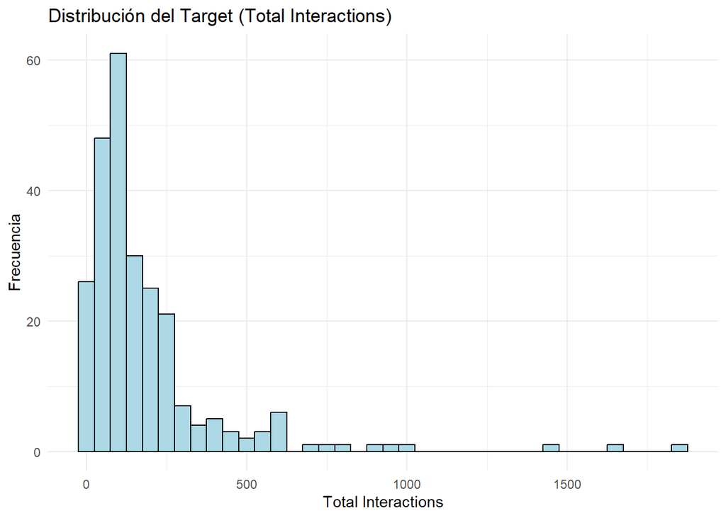

```r
#Histograma(Para ver la forma de la distribución):

ggplot(train, aes(x = `Total Interactions`)) +
  geom_histogram(binwidth = 50, fill = "lightblue", color = "black") +
  theme_minimal() +
  labs(title = "Distribución del Target (Total Interactions)", x = "Total Interactions", y = "Frecuencia")
```

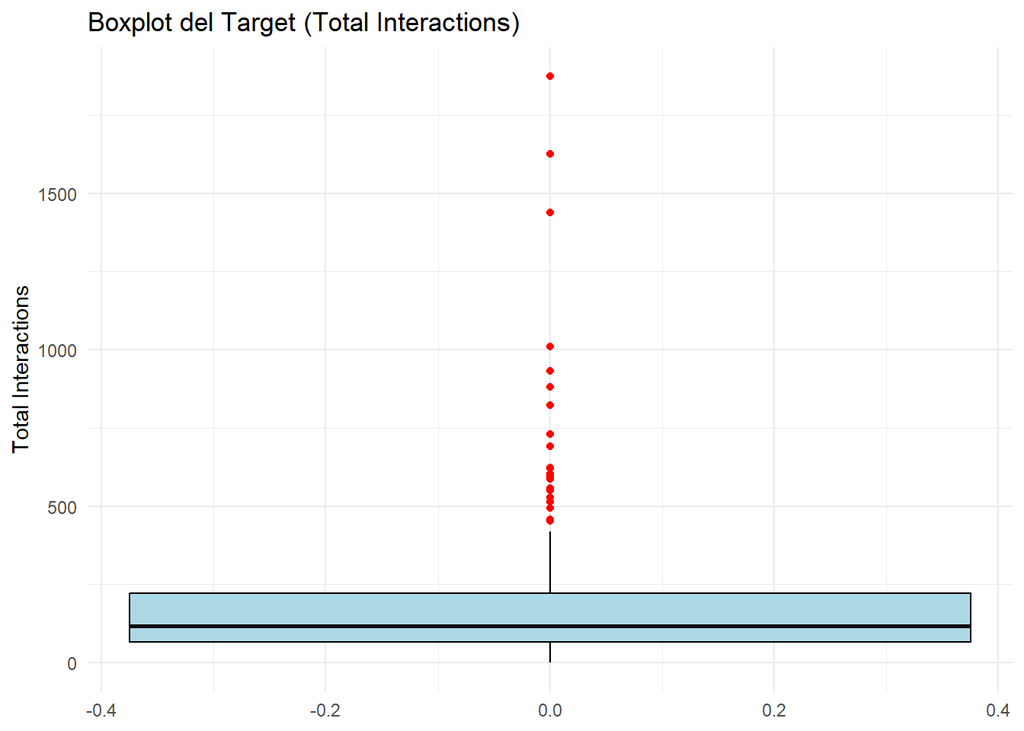

```r
#Boxplot(Para detectar outliers):

ggplot(train, aes(y = `Total Interactions`)) +
  geom_boxplot(fill = "lightblue", color = "black", outlier.colour = "red") +
  theme_minimal() +
  labs(title = "Boxplot del Target (Total Interactions)", y = "Total Interactions")
```

### Variables

#### Page total likes

Esta variable (Total de “me gusta” de la página) es el número de personas a las que les ha gustado la página de la empresa.

```r
summary(train$`Page total likes`)
```

```
##    Min. 1st Qu.  Median    Mean 3rd Qu.    Max.
##   81370  110158  128032  122570  136393  139441
```

El análisis de la variable Page total likes muestra que los valores oscilan entre un mínimo de 81,370 y un máximo de 139,441. La mediana se sitúa en 128,032, mientras que la media es ligeramente menor, con un valor de 122,570, lo que sugiere una leve asimetría hacia la izquierda. Esto indica que la mayoría de las publicaciones tienen un número de likes relativamente alto, concentrándose entre los valores de 120,000 y 140,000, aunque existen algunas con menos de 100,000 likes.

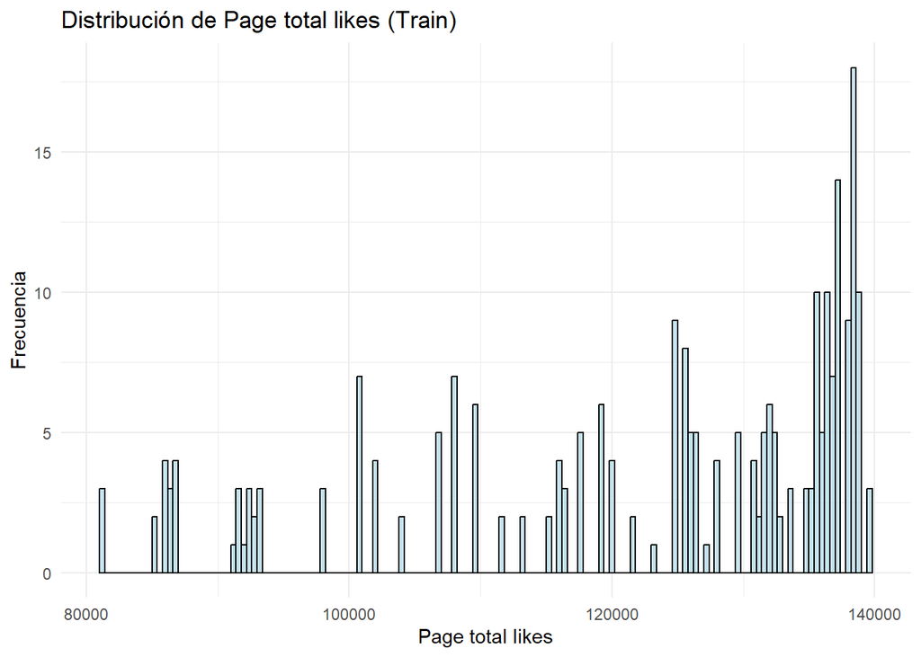

```r
# Histograma de "Page total likes" en el conjunto de entrenamiento
ggplot(train, aes(x = train$`Page total likes`)) +
  geom_histogram(binwidth = 400, fill = "lightblue", color = "black", alpha = 0.7) +
  theme_minimal() +
  labs(title = "Distribución de Page total likes (Train)", x = "Page total likes", y = "Frecuencia")
```

Al observar el histograma, se aprecia que la distribución de los likes no es completamente uniforme, sino que tiende a agruparse en los valores más elevados.

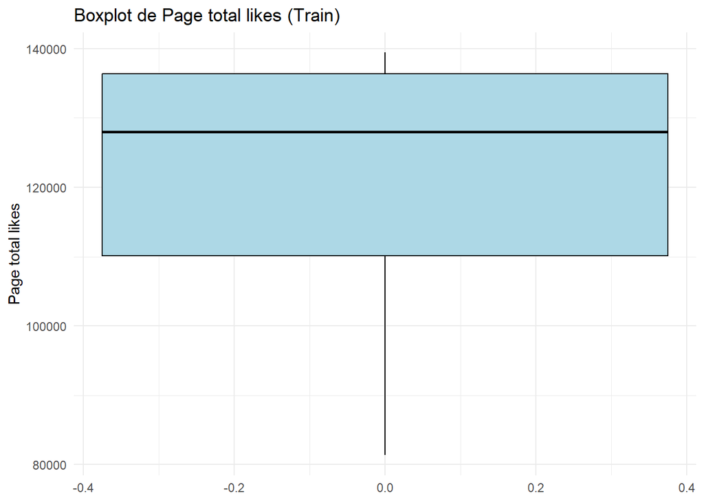

```r
# Boxplot de "Page total likes" en el conjunto de entrenamiento
ggplot(train, aes(y = train$`Page total likes`)) +
  geom_boxplot(fill = "lightblue", color = "black", outlier.colour = "red", outlier.size = 2) +
  theme_minimal() +
  labs(title = "Boxplot de Page total likes (Train)", y = "Page total likes")
```

El boxplot refuerza esta idea, mostrando que la mayor parte de los datos se encuentra dentro de un rango definido, sin valores extremos que se consideren atípicos.

```r
#  Page total likes
cor(train$`Total Interactions`, train$`Page total likes`, use="complete.obs")  # Correlación
```

```
## [1] 0.01749545
```

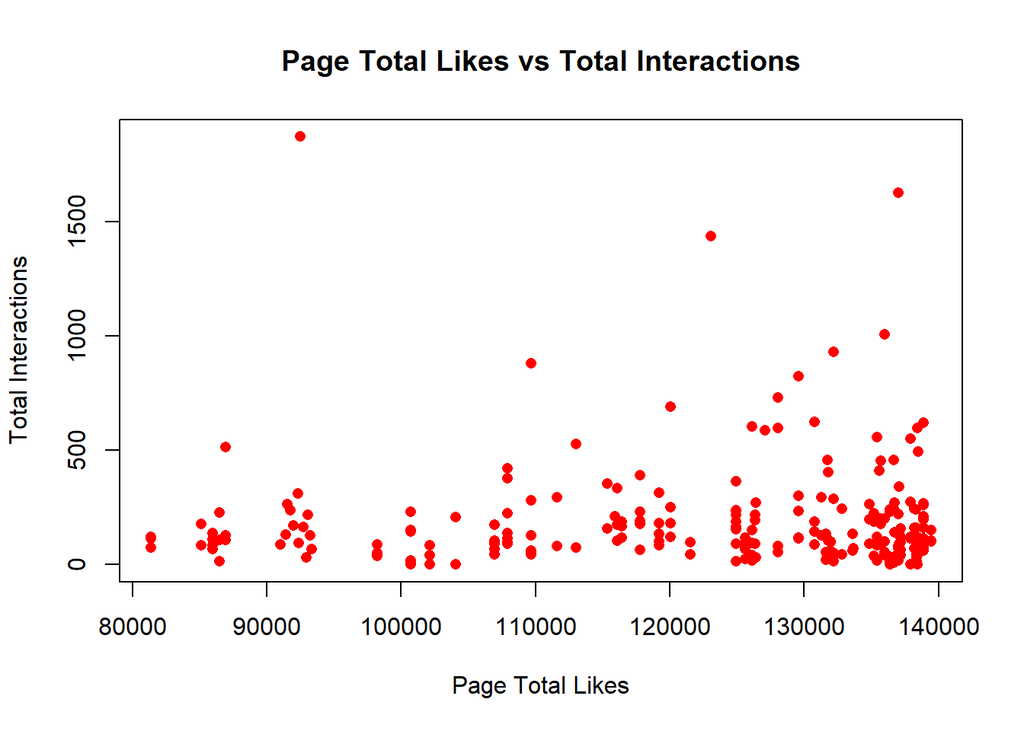

```r
plot(train$`Page total likes`, train$`Total Interactions`,
     main="Page Total Likes vs Total Interactions",
     xlab="Page Total Likes", ylab="Total Interactions",
     col="red", pch=16)
```

En cuanto a la relación entre Page total likes y Total Interactions, la correlación obtenida es muy baja y positiva, lo que indica que el número de likes en una página no determina de manera significativa el nivel de interacción de sus publicaciones. El diagrama de dispersión confirma esta observación, ya que no se percibe una tendencia clara entre ambas variables. Hay casos en los que páginas con un menor número de likes generan una gran cantidad de interacciones, mientras que otras con más likes no necesariamente logran el mismo nivel de engagement.

Esto sugiere que la cantidad de likes en una página no es el único factor que influye en la interacción del público. Es probable que variables como el tipo de publicación, la hora en la que se publica o el contenido del mensaje tengan un impacto mayor en el número de interacciones.

#### Type

En cuanto a ala varible Tipo, se trata del tipo de contenido (Enlace, Foto, Estado, Vídeo).

```r
summary(train$`Type`)
```

```
##    Length     Class      Mode
##       250 character character
```

```r
table(train$Type)
```

```
##
##   Link  Photo Status  Video
##     15    212     20      3
```

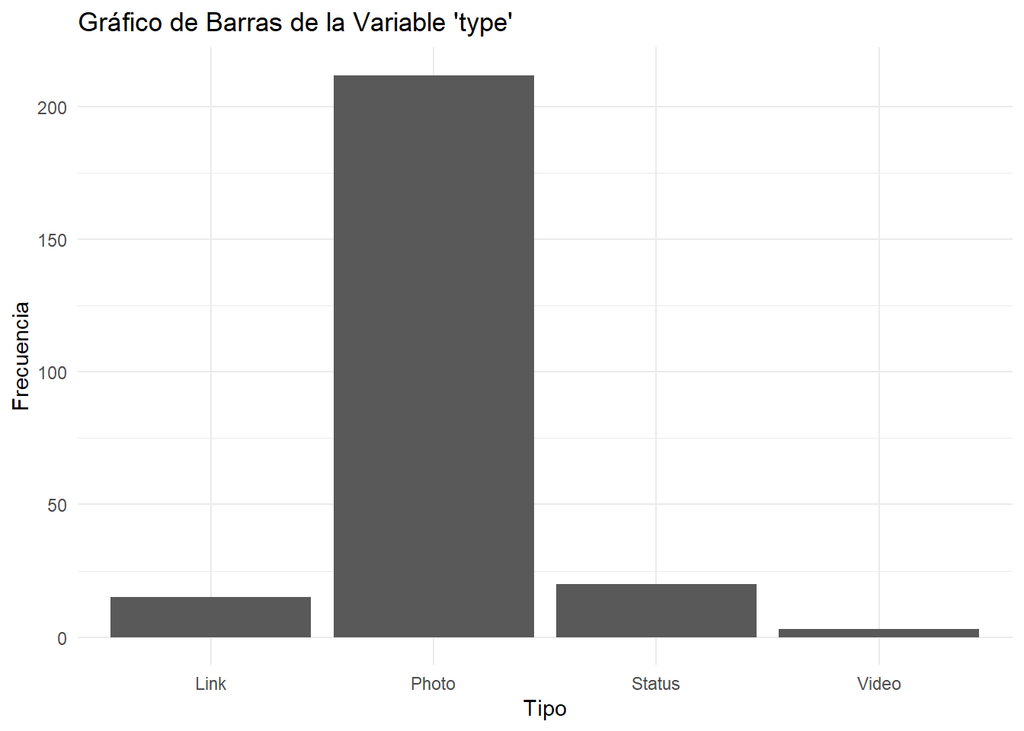

```r
# Crear un gráfico de barras
ggplot(train, aes(x = Type)) +
  geom_bar() +
  labs(title = "Gráfico de Barras de la Variable 'type'",
       x = "Tipo",
       y = "Frecuencia") +
  theme_minimal()
```

Se puede ver que predominan las fotos ante el resto.

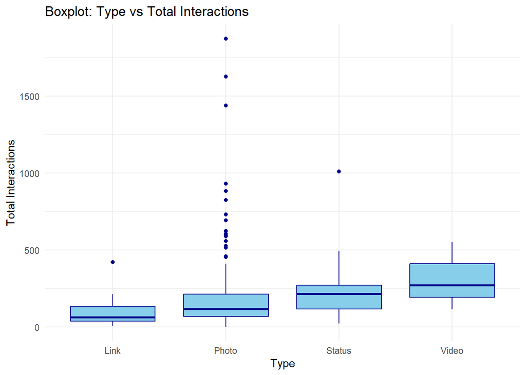

```r
# Crear un boxplot para enfrentar la variable categórica con el target
ggplot(train, aes(x = as.factor(Type), y = `Total Interactions`)) +
  geom_boxplot(fill = "skyblue", color = "darkblue") +
  labs(title = "Boxplot: Type vs Total Interactions",
       x = "Type",
       y = "Total Interactions") +
  theme_minimal()
```

Photo parece ser el tipo de contenido más propenso a generar interacciones extremas (outliers). Esto podría reflejar que las fotos tienen un mayor potencial de viralización.

Video tiene una dispersión más grande en las interacciones, pero menos valores atípicos, lo que podría sugerir un desempeño más uniforme, con publicaciones tanto exitosas como mediocres.

Las publicaciones de tipo Link parecen ser las que generan menos interacciones, con poca variación y pocos outliers.

#### Category

La variable categoría es la caracterización manual de contenido: acción (ofertas especiales y concursos), producto (publicidad directa, contenido explícito relacionado con la marca) e inspiración (contenido no explícito relacionado con la marca).

```r
summary(train$Category)
```

```
##    Min. 1st Qu.  Median    Mean 3rd Qu.    Max.
##   1.000   1.000   2.000   1.888   3.000   3.000
```

```r
table(train$Category)
```

```
##
##   1   2   3
## 107  64  79
```

El 1 reprsenta “Action”, el 2 es “Product” y el 3 es “Inspiration”.

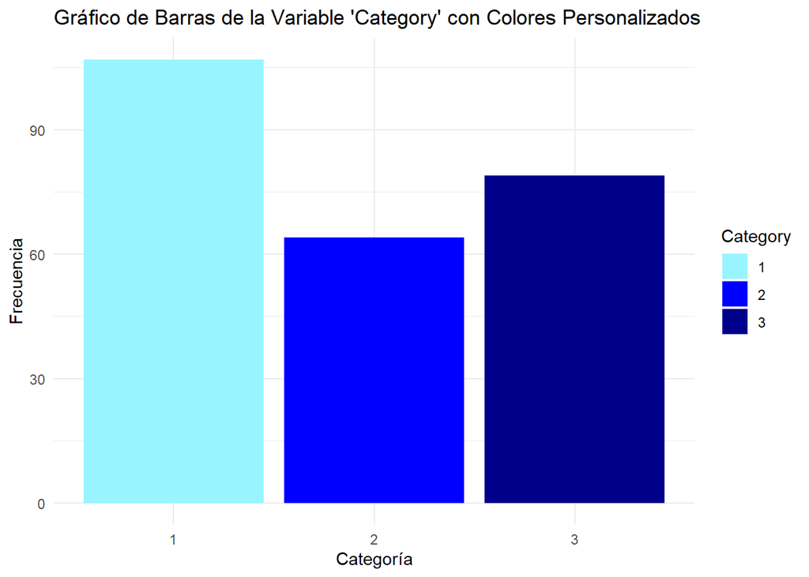

```r
# Convertir Category en un factor (si no lo es ya)
train$Category <- as.factor(train$Category)

# Crear el gráfico de barras con colores personalizados
ggplot(train, aes(x = Category, fill = Category)) +
  geom_bar() +
  scale_fill_manual(values = c("#98F5FF", "blue", "darkblue")) +  # Paleta manual
  labs(title = "Gráfico de Barras de la Variable 'Category' con Colores Personalizados",
       x = "Categoría",
       y = "Frecuencia") +
  theme_minimal()
```

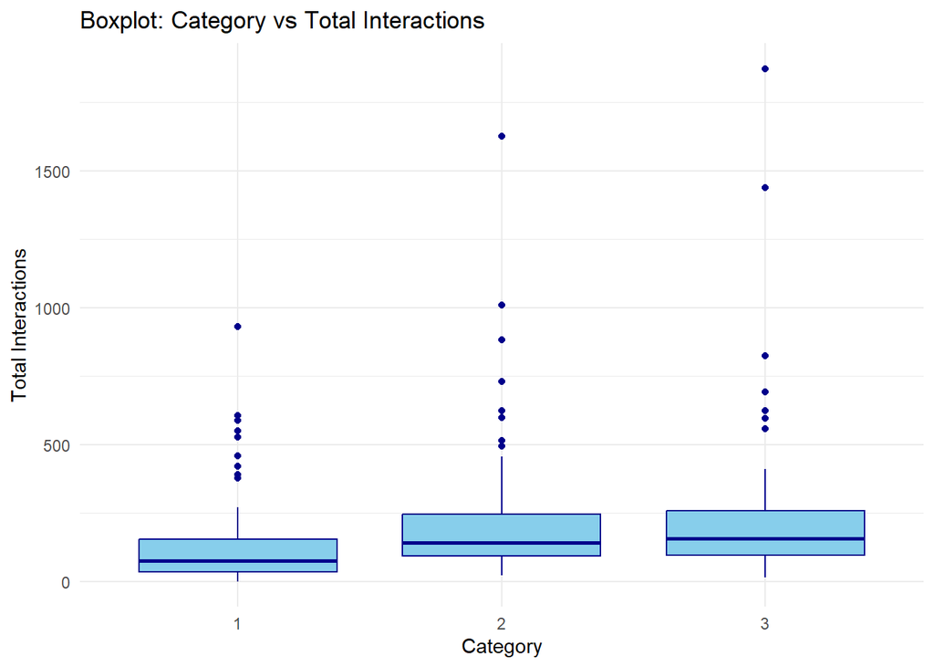

```r
## Crear un boxplot para enfrentar la variable categórica con el target
ggplot(train, aes(x = as.factor(Category), y = `Total Interactions`)) +
  geom_boxplot(fill = "skyblue", color = "darkblue") +
  labs(title = "Boxplot: Category vs Total Interactions",
       x = "Category",
       y = "Total Interactions") +
  theme_minimal()
```

#### Post Month

La variable “Mes del posteo” se trata del mes en que se publicó el post (enero, febrero, marzo,…, diciembre).

```r
summary(train$`Post Month`)
```

```
##    Min. 1st Qu.  Median    Mean 3rd Qu.    Max.
##   1.000   4.000   7.000   6.936  10.000  12.000
```

```r
table(train$`Post Month`)
```

```
##
##  1  2  3  4  5  6  7  8  9 10 11 12
## 16 13 16 25 22 28 22 16 12 32 20 28
```

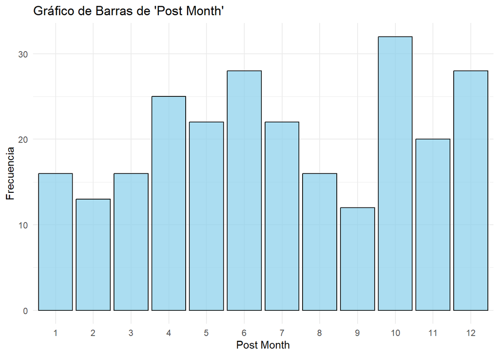

```r
# Crear un gráfico de barras para la variable 'Post Month'
ggplot(train, aes(x = factor(`Post Month`))) +
  geom_bar(fill = "skyblue", color = "black", alpha = 0.7) +
  labs(title = "Gráfico de Barras de 'Post Month'",
       x = "Post Month",
       y = "Frecuencia") +
  theme_minimal()
```

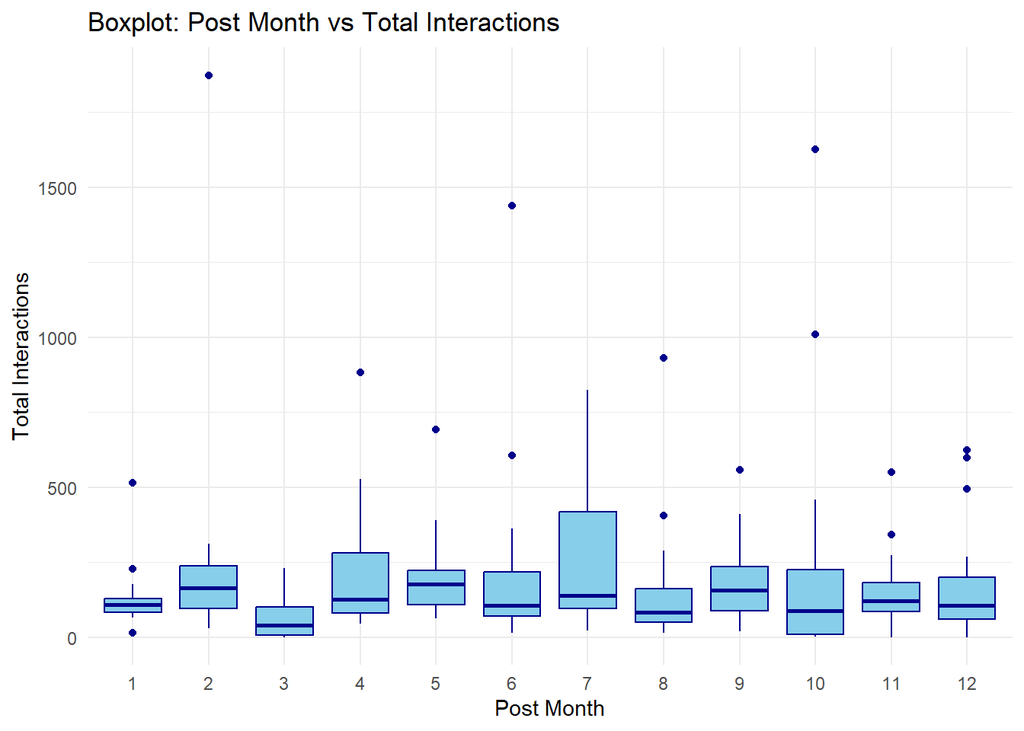

```r
# Crear un boxplot para enfrentar la variable categórica con el target
ggplot(train, aes(x = as.factor(`Post Month`), y = `Total Interactions`)) +
  geom_boxplot(fill = "skyblue", color = "darkblue") +
  labs(title = "Boxplot: Post Month vs Total Interactions",
       x = "Post Month",
       y = "Total Interactions") +
  theme_minimal()
```

Algunos meses muestran una mayor dispersión de interacciones (como en julio y octubre), lo que indica que hubo publicaciones con interacciones muy por encima del promedio.

Se observan outliers en varios meses, lo que sugiere que hubo publicaciones excepcionales con interacciones inusualmente altas.

Los meses 7 (julio) y 10 (octubre) parecen tener la mayor variabilidad en interacciones.

No parece haber una tendencia clara en la estacionalidad de las interacciones a lo largo de los meses.

Algunos meses tienen más publicaciones virales (con valores extremos), pero la mayoría de los meses tienen una distribución de interacciones relativamente baja y estable.

#### Post Weekday

Esta variable trata del día de la semana en que se publicó la entrada (domingo, lunes, …, sábado).

```r
summary(train$`Post Weekday`)
```

```
##    Min. 1st Qu.  Median    Mean 3rd Qu.    Max.
##   1.000   2.000   4.000   4.028   6.000   7.000
```

```r
table(train$`Post Weekday`)
```

```
##
##  1  2  3  4  5  6  7
## 37 35 32 36 36 38 36
```

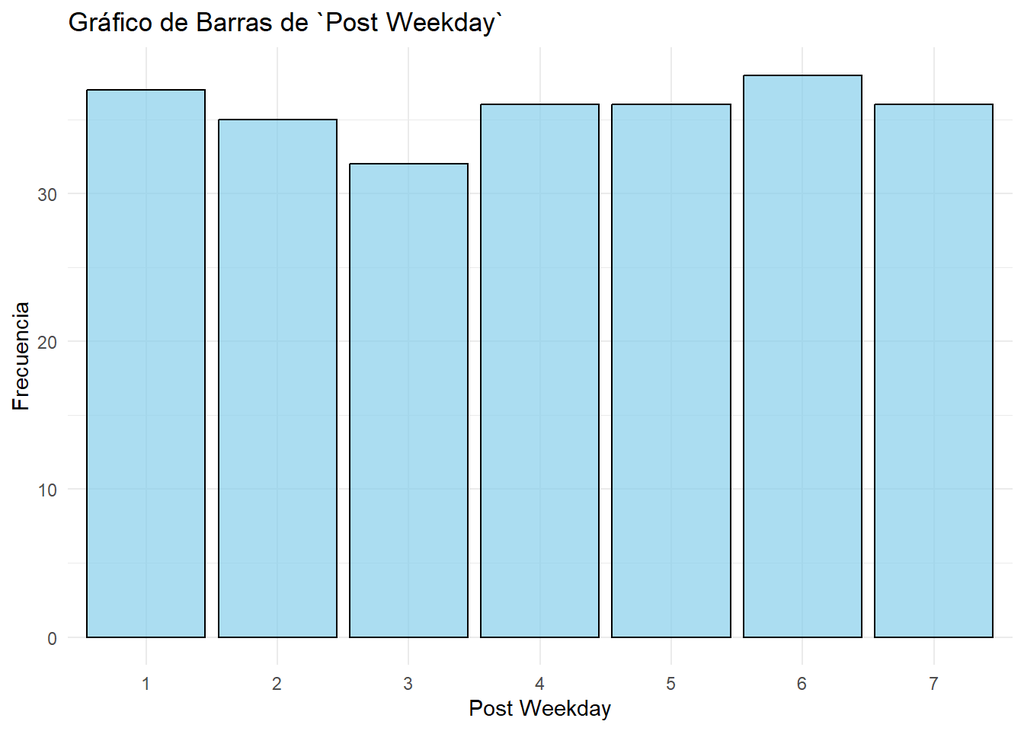

```r
# Crear un gráfico de barras para la variable 'Post Month'
ggplot(train, aes(x = factor(`Post Weekday`))) +
  geom_bar(fill = "skyblue", color = "black", alpha = 0.7) +
  labs(title = "Gráfico de Barras de `Post Weekday`",
       x = "Post Weekday",
       y = "Frecuencia") +
  theme_minimal()
```

```r
#enfrentamiento con el target
cor(train$`Total Interactions`, train$`Post Weekday`, use="complete.obs")  # Correlación
```

```
## [1] -0.06565487
```

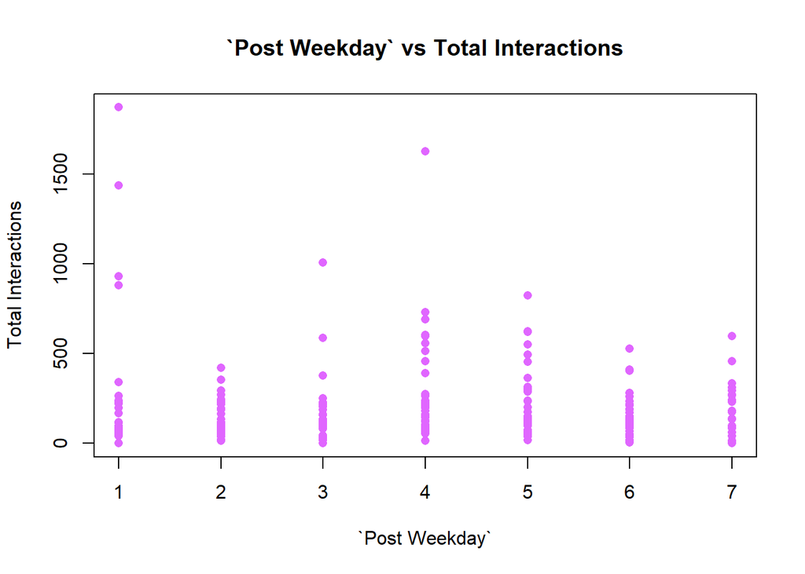

```r
plot(train$`Post Weekday`, train$`Total Interactions`, main="`Post Weekday` vs Total Interactions",
     xlab="`Post Weekday`", ylab="Total Interactions", col="#E066FF", pch=16)
```

No parece haber una relación importante entre el día de la semana de la publicación y las interacciones. Esto indica que el día de la semana no tiene un impacto notable en la cantidad de interacciones en las publicaciones.

#### Post Hour

Esta variable es la hora de publicación de la publicación (0, 1, 2, 3, 4, …, 23)

```r
summary(train$`Post Hour`)
```

```
##    Min. 1st Qu.  Median    Mean 3rd Qu.    Max.
##   1.000   3.000   9.000   7.836  11.000  23.000
```

```r
table(train$`Post Hour`)
```

```
##
##  1  2  3  4  5  6  7  8  9 10 11 12 13 14 15 17 19 20 23
##  2 22 49 23  4  9  4  6 16 30 26 16 27  8  4  1  1  1  1
```

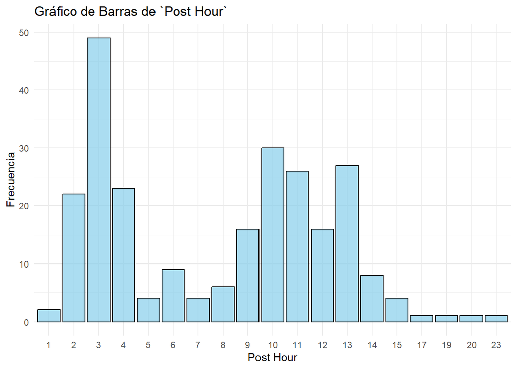

```r
# Crear un gráfico de barras para la variable 'Post Month'
ggplot(train, aes(x = factor(`Post Hour`))) +
  geom_bar(fill = "skyblue", color = "black", alpha = 0.7) +
  labs(title = "Gráfico de Barras de `Post Hour`",
       x = "Post Hour",
       y = "Frecuencia") +
  theme_minimal()
```

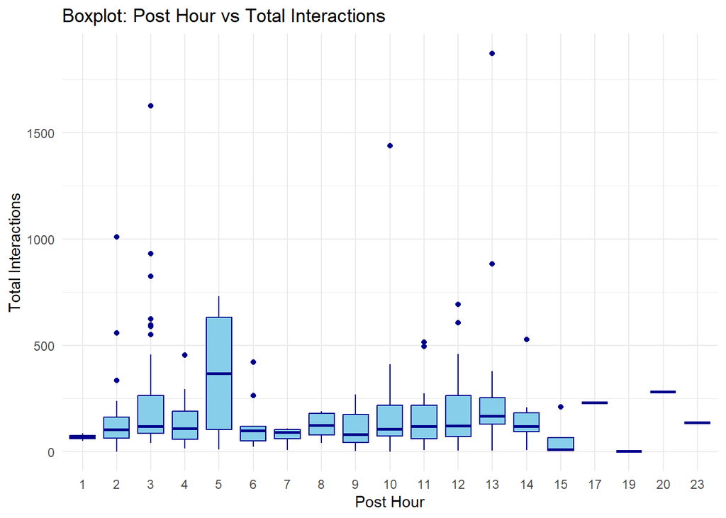

```r
# Crear un boxplot para enfrentar la variable categórica con el target
ggplot(train, aes(x = as.factor(`Post Hour`), y = `Total Interactions`)) +
  geom_boxplot(fill = "skyblue", color = "darkblue") +
  labs(title = "Boxplot: Post Hour vs Total Interactions",
       x = "Post Hour",
       y = "Total Interactions") +
  theme_minimal()
```

#### Paid

Esta varible trata de si la empresa pagó a Facebook por publicidad (0=no, 1=sí).

```r
summary(train$Paid)
```

```
##    Min. 1st Qu.  Median    Mean 3rd Qu.    Max.    NA's
##  0.0000  0.0000  0.0000  0.2329  0.0000  1.0000       1
```

Tenemos 1 NA, el cual lo eliminamos

```r
train_clean <- train %>%
  filter(!is.na(Paid))
```

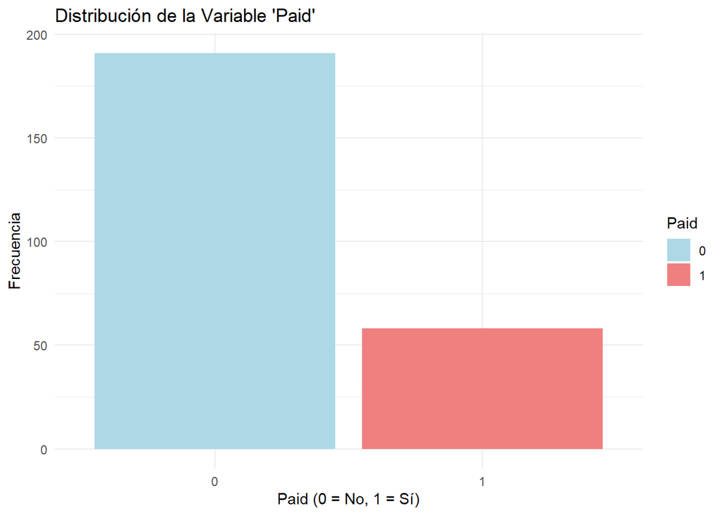

```r
# Gráfico de barras
ggplot(train_clean, aes(x = as.factor(Paid), fill = as.factor(Paid))) +
  geom_bar() +
  labs(title = "Distribución de la Variable 'Paid'",
       x = "Paid (0 = No, 1 = Sí)",
       y = "Frecuencia") +
  scale_fill_manual(values = c("lightblue", "lightcoral"), name = "Paid") +
  theme_minimal()
```

La barra azul hace referencia a las publicaciones que no fueron pagadas. Vemos que hay más del doble de publicaciones no pagadas que pagadas.

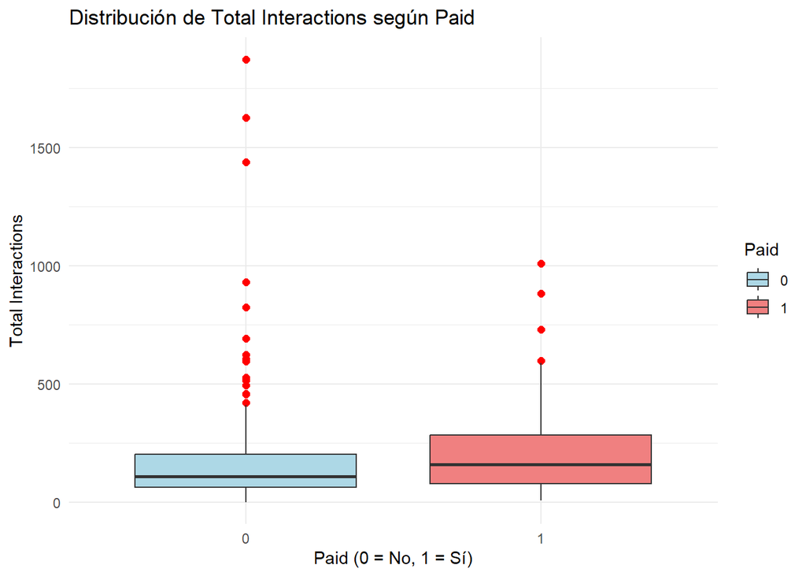

```r
ggplot(train_clean, aes(x = as.factor(Paid), y = `Total Interactions`, fill = as.factor(Paid))) +
  geom_boxplot(outlier.color = "red", outlier.shape = 16, outlier.size = 2) +
  labs(title = "Distribución de Total Interactions según Paid",
       x = "Paid (0 = No, 1 = Sí)",
       y = "Total Interactions") +
  scale_fill_manual(values = c("lightblue", "lightcoral"), name = "Paid") +
  theme_minimal()
```

Este boxplot nos ayuda a ver la correlación de Paid con la variable objetivo. La correlación es baja y positiva. Hay una relación débil y positiva entre las interacciones y si el post fue pagado o no, pero no es significativa.

#### Lifetime Post Total Reach

Es el número de personas alcanzadas, es decir,la cantidad de personas que vieron una publicación de la página (usuarios únicos).

```r
summary(train$'Lifetime Post Total Reach')
```

```
##    Min. 1st Qu.  Median    Mean 3rd Qu.    Max.
##     238    3060    4925   13316   11577  139008
```

Los valores se encuentran entre un mínimo de 238 y un máximo de 139008. La mediana es 4925, mientras que la media tiene un valor de 13316. El hecho de que la media sea mucho mayor que la mediana sugiere que existen algunos valores atípicos (publicaciones con un alcance significativamente más alto) que están influyendo en la media, mientras que la mayoría de las publicaciones tienen un alcance no tal alto.

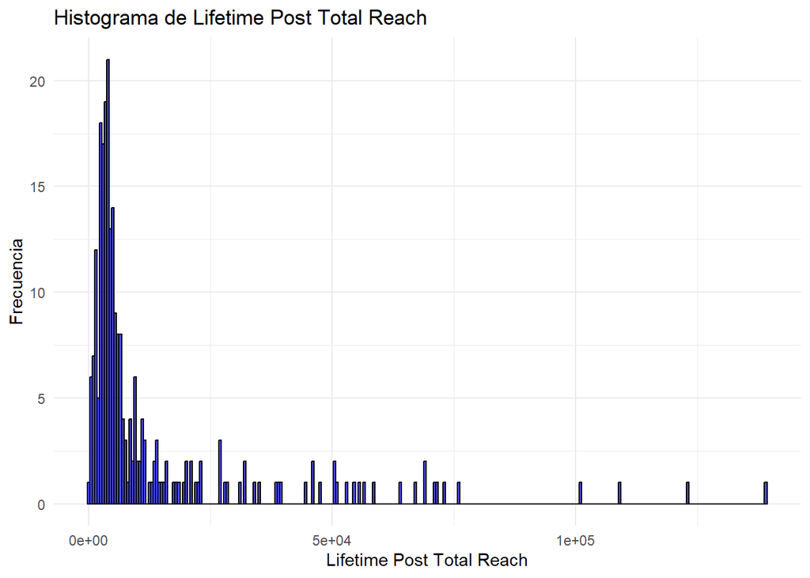

```r
# Histograma
ggplot(train, aes(x = `Lifetime Post Total Reach`)) +
  geom_histogram(binwidth = 500, fill = "blue", color = "black", alpha = 0.7) +
  labs(title = "Histograma de Lifetime Post Total Reach",
       x = "Lifetime Post Total Reach",
       y = "Frecuencia") +
  theme_minimal()
```

Podemos ver que la distribución de los datos no es uniforme. Se acumula en valores más bajos, con valores puntuales más altos.

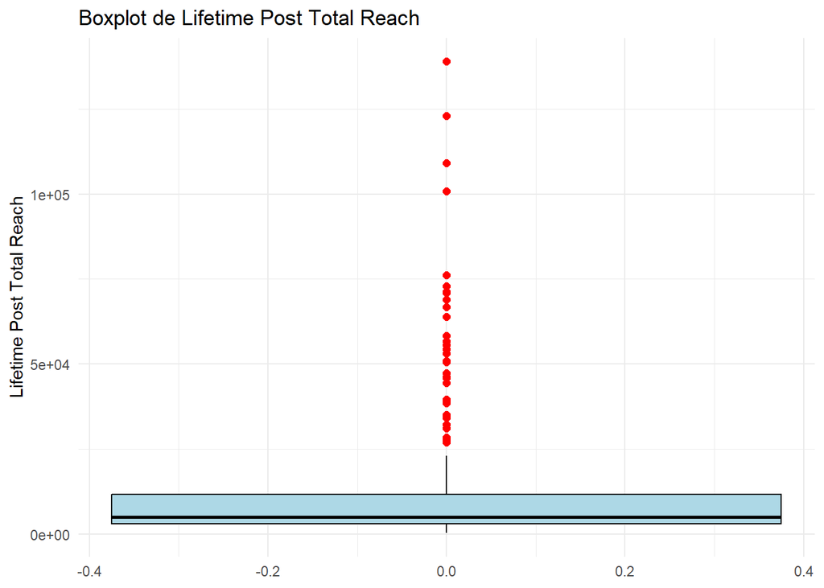

```r
# Boxplot de "Lifetime Post Total Reach"
ggplot(train, aes(y = train$`Lifetime Post Total Reach`)) +
  geom_boxplot(fill = "lightblue", color = "black", outlier.colour = "red", outlier.size = 2) +
  theme_minimal() +
  labs(title = "Boxplot de Lifetime Post Total Reach", y = "Lifetime Post Total Reach")
```

Con el boxplot confirmamos la idea que veíamos en el histograma.

```r
# Enfrentamiento con el target
cor(train$`Total Interactions`, train$`Lifetime Post Total Reach`, use="complete.obs")  # Correlación
```

```
## [1] 0.4627403
```

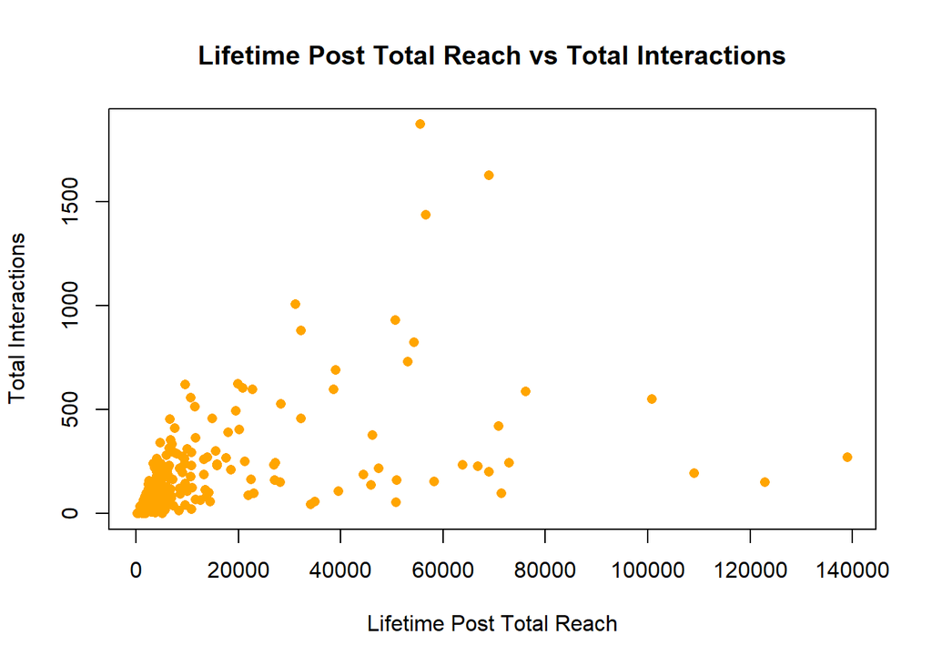

```r
plot(train$`Lifetime Post Total Reach`, train$`Total Interactions`, main="Lifetime Post Total Reach vs Total Interactions",
     xlab="Lifetime Post Total Reach", ylab="Total Interactions", col="orange", pch=16)
```

La correlación es moderada y positiva. Hay una relación moderada entre las interacciones y el alcance total de la publicación a lo largo de su vida.

#### Lifetime Post Total Impressions

Hace referencia al número de impresiones totales. Las impresiones son el número de veces que se muestra una publicación de una página, independientemente de si se hace clic en ella. Es posible que se vean varias impresiones de la misma publicación. Por ejemplo, alguien podría ver una actualización de una página en la sección de noticias una vez y luego otra si un amigo la comparte.

```r
summary(train$'Lifetime Post Total Impressions')
```

```
##    Min. 1st Qu.  Median    Mean 3rd Qu.    Max.
##     570    5419    8379   26904   20366  665792
```

Los valores se encuentran entre un mínimo de 570 y un máximo de 665792. La mediana es 8379, mientras que la media tiene un valor de 26904. Al igual que ocurría antes,el hecho de que la media sea mucho mayor que la mediana sugiere que existen algunos valores atípicos que están influyendo en la media, mientras que la mayoría de las publicaciones tienen un alcance no tal alto.

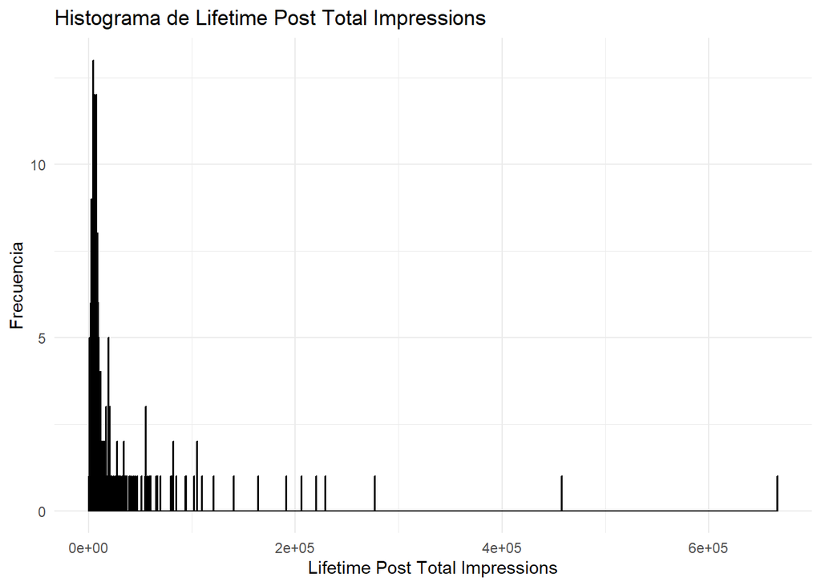

```r
# Histograma
ggplot(train, aes(x = `Lifetime Post Total Impressions`)) +
  geom_histogram(binwidth = 500, fill = "blue", color = "black", alpha = 0.7) +
  labs(title = "Histograma de Lifetime Post Total Impressions",
       x = "Lifetime Post Total Impressions",
       y = "Frecuencia") +
  theme_minimal()
```

De nuevo sucede que la distribución de los datos no es uniforme, sino que se acumula en valores más bajos, con valores puntuales más altos.

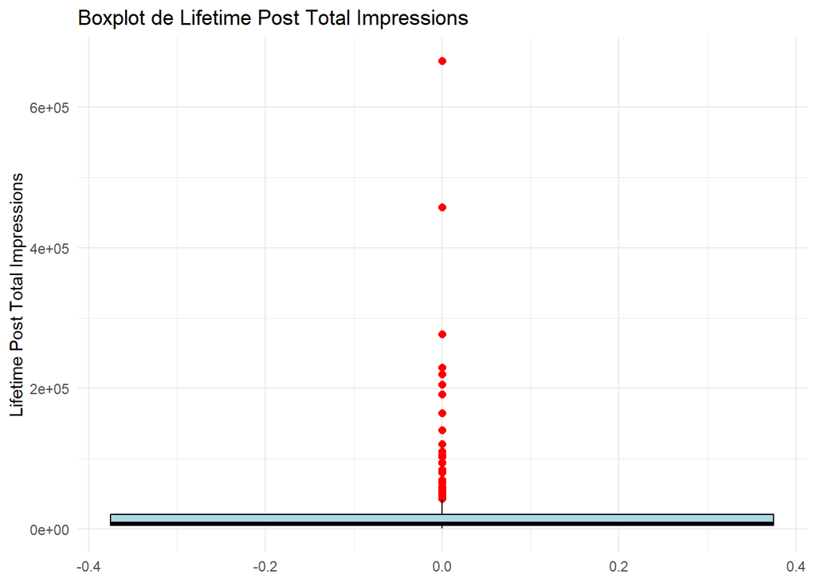

```r
# Boxplot de 'Lifetime Post Total Impressions'
ggplot(train, aes(y = train$`Lifetime Post Total Impressions`)) +
  geom_boxplot(fill = "lightblue", color = "black", outlier.colour = "red", outlier.size = 2) +
  theme_minimal() +
  labs(title = "Boxplot de Lifetime Post Total Impressions", y = "Lifetime Post Total Impressions")
```

```r
# Enfrentamiento con el target
# Lifetime Post Total Impressions
cor(train$`Total Interactions`, train$`Lifetime Post Total Impressions`, use="complete.obs")  # Correlación
```

```
## [1] 0.5263939
```

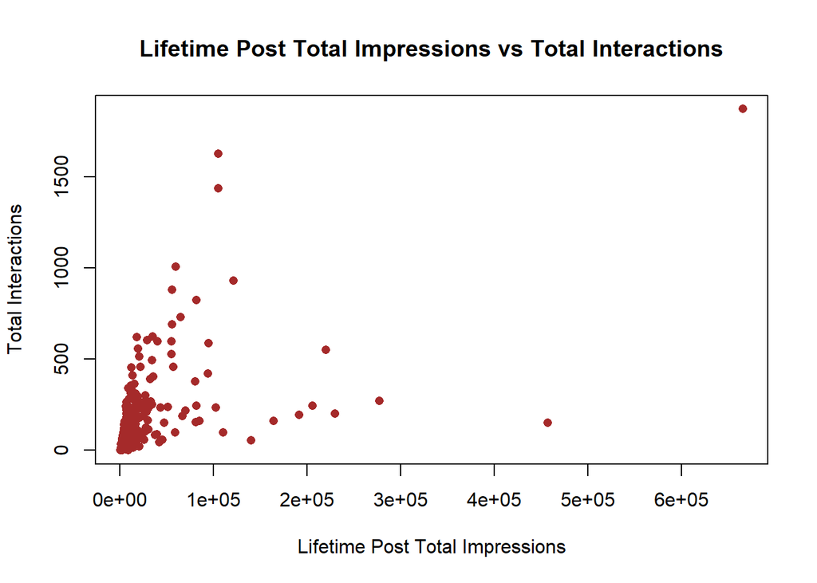

```r
plot(train$`Lifetime Post Total Impressions`, train$`Total Interactions`, main="Lifetime Post Total Impressions vs Total Interactions",
     xlab="Lifetime Post Total Impressions", ylab="Total Interactions", col="brown", pch=16)
```

La correlación es moderada y positiva. Existe una relación moderada entre las interacciones y el total de impresiones de la publicación durante su vida.

#### Lifetime Engaged Users

Es el número de personas que interactuaron con la publicación, la cantidad de personas que hicieron clic en cualquier parte de una publicación (usuarios únicos).

```r
summary(train$'Lifetime Engaged Users')
```

```
##    Min. 1st Qu.  Median    Mean 3rd Qu.    Max.
##    15.0   365.8   580.5   843.2  1040.2  6164.0
```

[figure not shown]

```r
# Histograma
ggplot(train, aes(x = `Lifetime Engaged Users`)) +
  geom_histogram(binwidth = 500, fill = "skyblue", color = "black", alpha = 0.7) +
  labs(title = "Histograma de Lifetime Engaged Users",
       x = "Lifetime Post Total Reach",
       y = "Frecuencia") +
  theme_minimal()
```

Esta variable se acumula en valores más bajos, lo que indica que la mayoría de las publicaciones tienen un alcance bajo y pocos usuarios comprometidos, mientras que solo unas pocas publicaciones logran un alcance elevado.

[figure not shown]

```r
# Boxplot de "Lifetime Engaged Users"
ggplot(train, aes(y = train$`Lifetime Post Total Reach`)) +
  geom_boxplot(fill = "lightblue", color = "black", outlier.colour = "red", outlier.size = 2) +
  theme_minimal() +
  labs(title = "Boxplot de Lifetime Engaged Users", y = "Lifetime Engaged Users")
```

Vemos que la mayoría de las publicaciones tienen valores bajos, pero que hay bastantes valores atípicos con valores más altos.

```r
#enfrentamiento con el target (Lucía)
# Lifetime Engaged Users
cor(train$`Total Interactions`, train$`Lifetime Engaged Users`, use="complete.obs")  # Correlación
```

```
## [1] 0.6438378
```

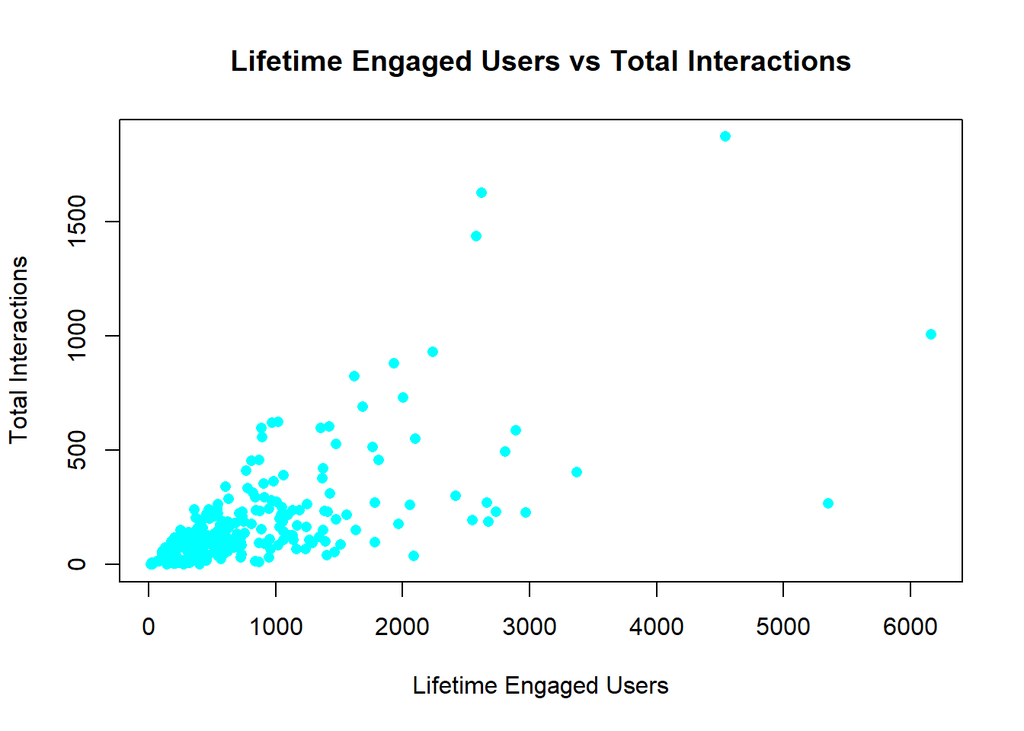

```r
plot(train$`Lifetime Engaged Users`, train$`Total Interactions`, main="Lifetime Engaged Users vs Total Interactions",
     xlab="Lifetime Engaged Users", ylab="Total Interactions", col="cyan", pch=16)
```

La correlación es moderada-alta y positiva. Hay una relación bastante fuerte entre las interacciones y los usuarios comprometidos con la publicación.

#### Lifetime Post Consumers

Es el número de personas que consumieron el contenido. Esto es la cantidad de personas que hicieron clic en cualquier parte de una publicación.

```r
summary(train$'Lifetime Post Consumers')
```

```
##    Min. 1st Qu.  Median    Mean 3rd Qu.    Max.
##    15.0   322.0   523.5   738.0   936.2  5934.0
```

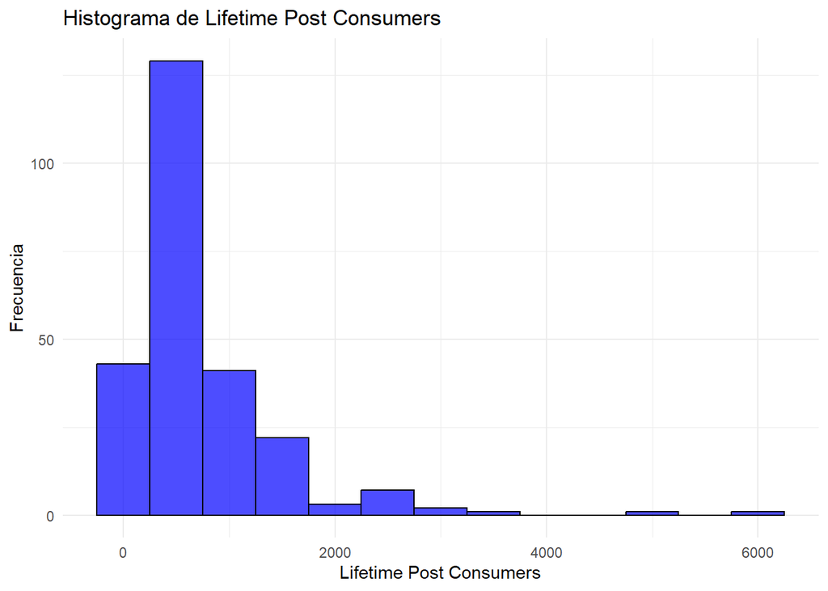

```r
# Histograma
ggplot(train, aes(x = `Lifetime Post Consumers`)) +
  geom_histogram(binwidth = 500, fill = "blue", color = "black", alpha = 0.7) +
  labs(title = "Histograma de Lifetime Post Consumers",
       x = "Lifetime Post Consumers",
       y = "Frecuencia") +
  theme_minimal()
```

Es una distribución bastante similar a la anterior.

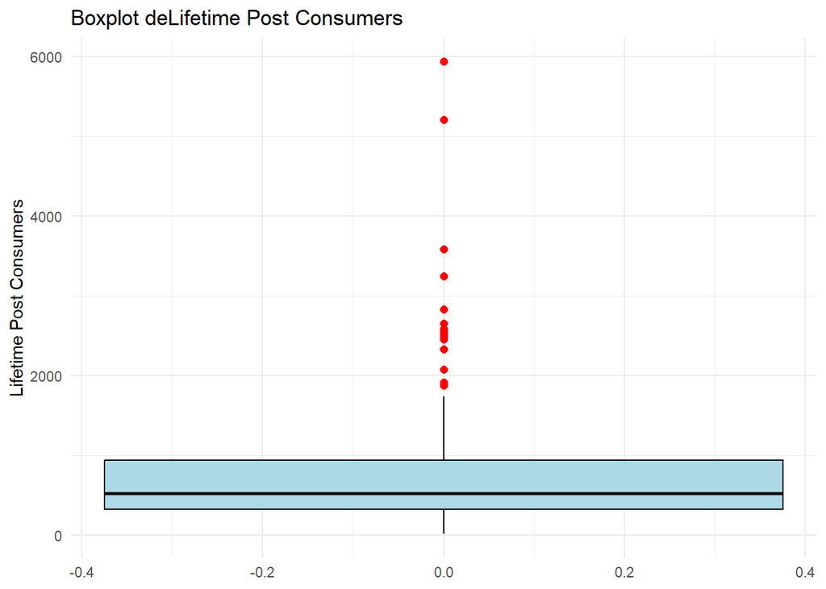

```r
# Boxplot de 'Lifetime Post Consumers'
ggplot(train, aes(y = train$`Lifetime Post Consumers`)) +
  geom_boxplot(fill = "lightblue", color = "black", outlier.colour = "red", outlier.size = 2) +
  theme_minimal() +
  labs(title = "Boxplot deLifetime Post Consumers", y = "Lifetime Post Consumers")
```

```r
#enfrentamiento con el target (Lucía)
# Lifetime Post Consumers
cor(train$`Total Interactions`, train$`Lifetime Post Consumers`, use="complete.obs")  # Correlación
```

```
## [1] 0.4924551
```

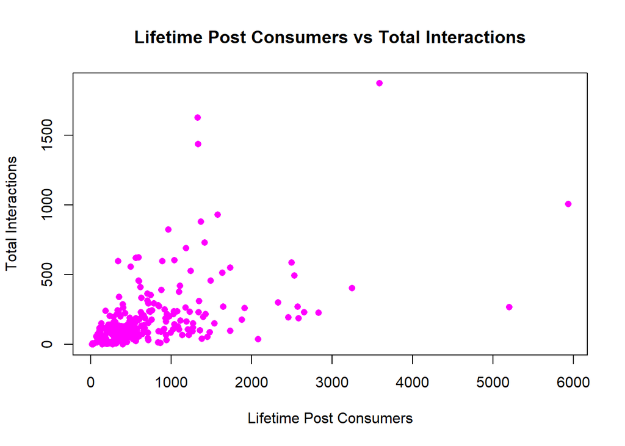

```r
plot(train$`Lifetime Post Consumers`, train$`Total Interactions`, main="Lifetime Post Consumers vs Total Interactions",
     xlab="Lifetime Post Consumers", ylab="Total Interactions", col="magenta", pch=16)
```

La correlación es moderada y positiva. Hay una relación moderada entre las interacciones y el número de consumidores de la publicación.

#### Lifetime Post Consumptions

Esta variable se refiere al número de interacciones con el contenido, es decir, el número de clics en cualquier parte de una publicación.

```r
summary(train$`Lifetime Post Consumptions`)
```

```
##    Min. 1st Qu.  Median    Mean 3rd Qu.    Max.
##    19.0   477.5   788.0  1356.0  1421.2 19779.0
```

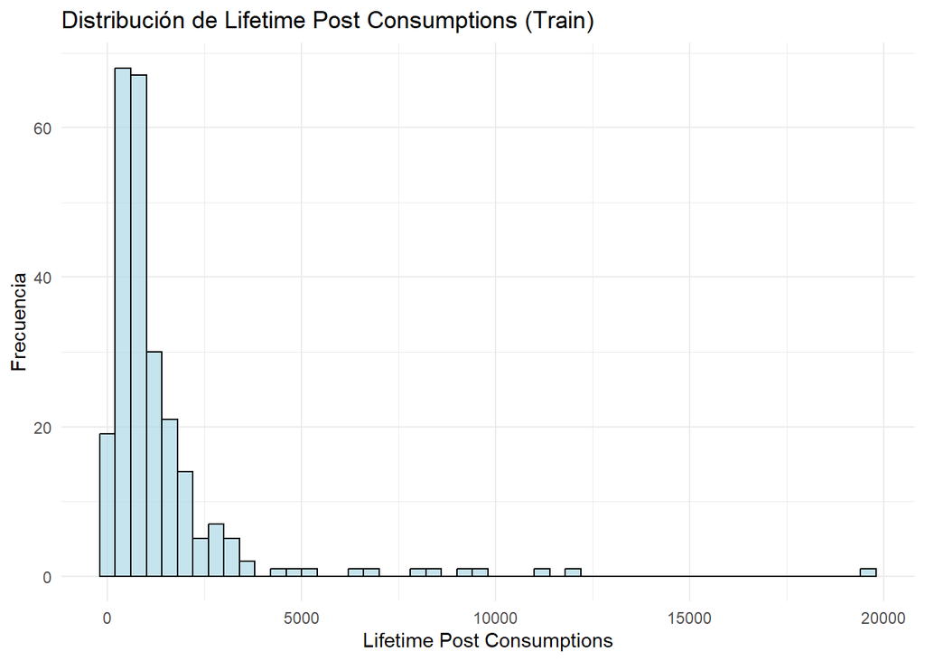

```r
# Histograma
ggplot(train, aes(x = train$`Lifetime Post Consumptions`)) +
  geom_histogram(binwidth = 400, fill = "lightblue", color = "black", alpha = 0.7) +
  theme_minimal() +
  labs(title = "Distribución de Lifetime Post Consumptions (Train)",
       x = "Lifetime Post Consumptions", y = "Frecuencia")
```

```r
#enfrentamiento con el target (Lucía)
# Lifetime Post Consumptions
cor(train$`Total Interactions`, train$`Lifetime Post Consumptions`, use="complete.obs")  # Correlación
```

```
## [1] 0.258678
```

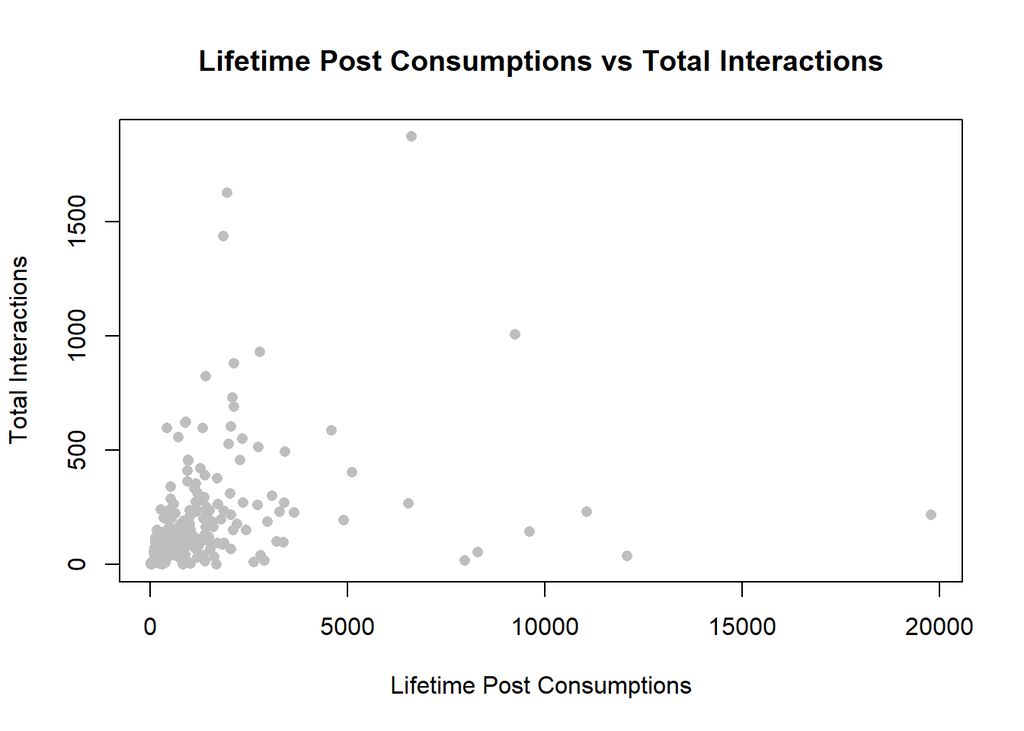

```r
plot(train$`Lifetime Post Consumptions`, train$`Total Interactions`, main="Lifetime Post Consumptions vs Total Interactions",
     xlab="Lifetime Post Consumptions", ylab="Total Interactions", col="gray", pch=16)
```

La correlación es baja y positiva. Hay una relación débil entre las interacciones y las consumiciones de la publicación.